# Project: Marketing Campaign Analysis

### **Question 5: Write the code and your observations on average number of purchases from different channels across all campaigns.** - 7 Marks

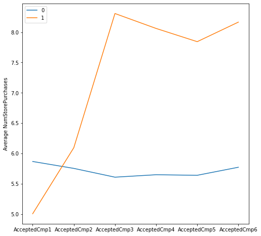

```python
# store purchase

#call the function Purchases_per_campaign for NumStorePurchases
Purchases_per_campaign('NumStorePurchases')
```

For the customers accepting campaign 3, 4, 5 and 6 the average average number of Store purchases are quite high.

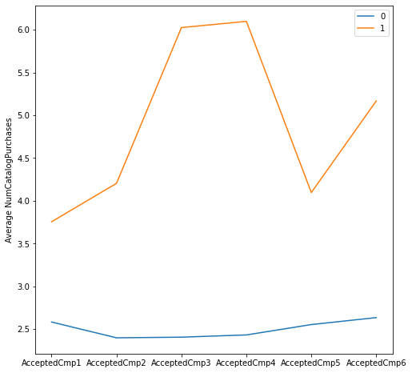

```python
#Catalog purchase

#call the function Purchases_per_campaign for NumCatalogPurchases

Purchases_per_campaign('NumCatalogPurchases')
```

For the customers accepting campaign 3, 4 and 6 the average average number of Catalog purchases are quite high.

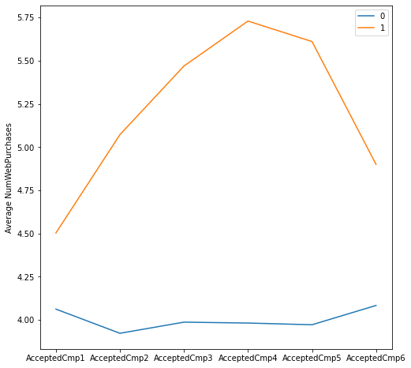

```python
#Web purchases

#call the function Purchases_per_campaign for NumWebPurchases

Purchases_per_campaign('NumWebPurchases')
```

For the customers accepting campaign 3, 4 and 5 the average average number of Web purchases are quite high.

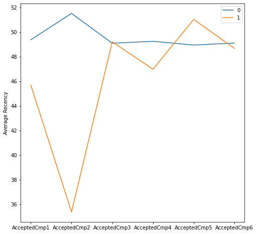

```python
#Recency

Purchases_per_campaign('Recency')
```

**Observations:**

- Average recency of the customers who accepted campaign 2 is quite low which implies that campaign 2 was accepted by the customers who recently purchased an item.

#### We have analyzed the relationship between campaigns and numerical variables. Let's see the relationship of campaigns with different categorical variables

We will check the percentage acceptance of each campaign with respect to each category in the categorical variable. The percentage acceptance is calculated as number of customers who have accepted the campaign to the total number of customers.

```python
def Cat_Campaign_Relation(df, column_name):
    e1=(df.groupby([column_name]).sum()['AcceptedCmp1']/df.groupby([column_name]).count()['AcceptedCmp1'])
    e2=(df.groupby([column_name]).sum()['AcceptedCmp2']/df.groupby([column_name]).count()['AcceptedCmp2'])
    e3=(df.groupby([column_name]).sum()['AcceptedCmp3']/df.groupby([column_name]).count()['AcceptedCmp3'])
    e4=(df.groupby([column_name]).sum()['AcceptedCmp4']/df.groupby([column_name]).count()['AcceptedCmp4'])
    e5=(df.groupby([column_name]).sum()['AcceptedCmp5']/df.groupby([column_name]).count()['AcceptedCmp5'])
    e6=(df.groupby([column_name]).sum()['AcceptedCmp6']/df.groupby([column_name]).count()['AcceptedCmp6'])
    df_new=pd.concat([e1,e2,e3,e4,e5,e6],axis=1).T
    plt.figure(figsize=(8,8))
    sns.lineplot(data=df_new, markers=True, linewidth=2)
    plt.ylabel('Percentage Acceptance')
    plt.show()
```

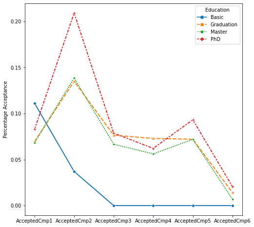

```python
#here is an example showing how to use this function on the column Education
Cat_Campaign_Relation(df, 'Education')
```

**Observations:**

- More than 20% of the customers with Ph.D have accepted campaign 2.
- Customers with basic education have only accepted campaign 1 and 2.
- Except customers with basic education level, all education levels follow the same trend.

### **Question 6: Write the code and your observations on percentage acceptance for different categorical variables across all campaigns.** - 7 Marks

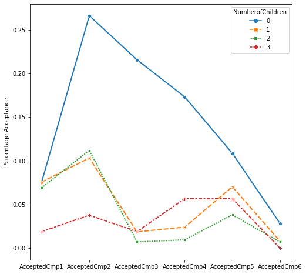

```python
#NumberofChildren

#call the function Cat_Campaign_Relation for NumberofChildren
Cat_Campaign_Relation(df, 'NumberofChildren')
```

Observations:

More than 20% of the customers have no child accepted campaign 2. Equal number of Customers having 1 and 3 children accepted Campaign 3. Equal number of Customers having no kid and 1 child have accepted campaign 1. Nearly equal number of customers having 1,2 and 3 children have accepted Campaign6.

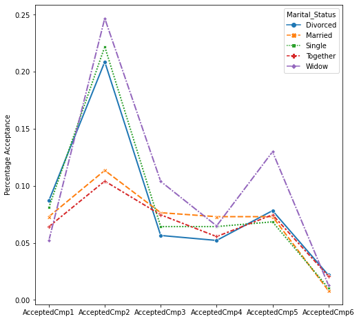

```python
#Let's filter the observations with 'Others' category as they are only 4 such observations
df_rest=df[df.Marital_Status!='Others']

#call the function Cat_Campaign_Relation for Marital_Status with dataframe df_rest
Cat_Campaign_Relation(df_rest,'Marital_Status')
```

Most of the Widows accepted Campaign 2. Least of the Together people accepted Campaign 2. Most Divorced people accepted campaign 1. Least of the Widows people accepted Campaign 1. Most of the Widows accepted Campaign 3. Least of the Divorced people accepted Campaign 3. Most of the Married people accepted Campaign 4. Least of the Divorced people accepted Campaign 4. Most of the Widow people accepted Campaign 5. Nearly equal number of Married,Single,Together and Divorced accepted Campaign 5. Nearly equal number of all the Categories accepted Campaign number 6.

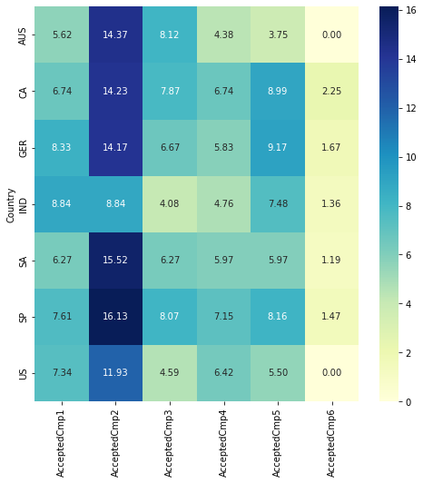

```python
#Let's filter the observations for 'ME' country as they are only 3 such observations
df_not_mexico=df[df.Country!='ME']

#Plot
plt.figure(figsize=(8,8))
sns.heatmap((df_not_mexico.groupby('Country').sum()[Camp_cols]/df_not_mexico.groupby('Country').count()[Camp_cols])*100, annot=True, fmt='0.2f', cmap="YlGnBu")
```

**Observation:**___**** Most of the US,SP,SA,IND,GER,CA and Aus population accepted Campaign 2. US and Aus did not accept Campaign 6. Most of the Indian population accepted Campaign 1 and 2.

### Check the product preferences by customers

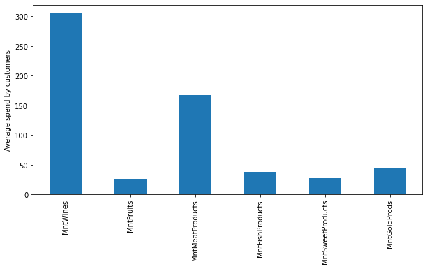

```python
#creating a list which contains name of all products

mnt_cols = [col for col in df.columns if 'Mnt' in col]

spending=df[mnt_cols].mean(axis=0)
spending.plot(kind='bar', figsize=(10,5))
plt.ylabel("Average spend by customers")
plt.show()
```

**Observations**:

- The mean amount spent by customers in the last 2 years is highest for wines followed by meat products.

Let's check if the product preferences are similar for different types of customers. We will calculate the percentage amount spent by customers on a product for each category with respect to the total spending by customers belonging to that category.

```python
def amount_per_category(df, column_name):
    df_new1=((df.groupby([column_name]).sum()[mnt_cols].T)/df.groupby([column_name]).sum()['Total_Spending'])
    plt.figure(figsize=(10,8))
    sns.heatmap(df_new1.T, annot=True, cmap="YlGnBu")
    plt.show()
```

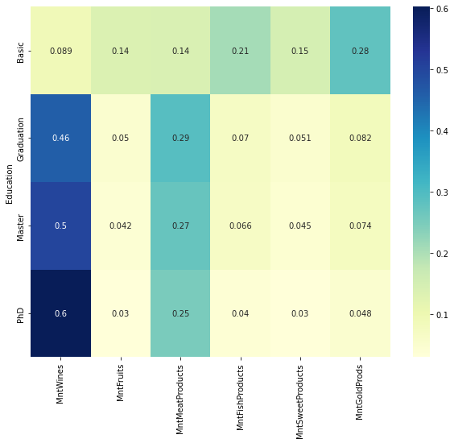

```python
# plot showing the percentage of total spending of different products by a group of customers having the same education level

amount_per_category(df, 'Education')
```

**Observations:**

- Customers with PhD spend ~60% of their total spending on wines.
- Customers with Graduation and Master's spend ~45-50% of their total spending on wines.
- Customers with Graduation and Master's spend ~27-29% of their total spending on meat.
- Customers with PhD spend ~25% of their total spending on meat.
- Customers having education level Master or PhD spend ~80% on meat and wines.
- Customers with basic education spend more on Fruits, Fish, Sweet, and Gold products.

### **Question 7: Write the code and your observations on percentage amount spent on different products for each category of the mentioned categorical variables.** - 7 Marks

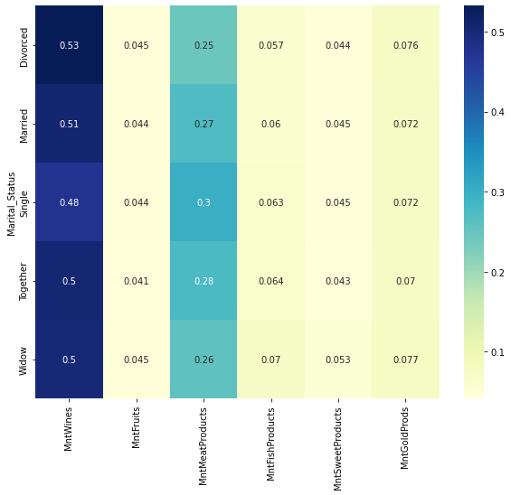

```python
#call the function amount_per_category for Marital_Status with dataframe df_rest

amount_per_category(df_rest, 'Marital_Status')
```

Observations:

Married,Together,Single,Widow and Divorced Customers spend ~50% of their total spending on wines. Married,Together,Single,Widow and Divorced Customers spend 25% to 30% of their total spending on meat. Married,Together,Single,Widow and Divorced Customers spend 75% to 80% of their total spending on meat and wines. Married,Together,Single,Widow and Divorced Customers spend around 4%-5% of their total spending on Fruits. Married,Together,Single,Widow and Divorced Customers spend around 5%-7% of their total spending on Fish. Married,Together,Single,Widow and Divorced Customers spend around 4%-5% of their total spending on Sweets. Married,Together,Single,Widow and Divorced Customers spend around ~7.5% of their total spending on Gold.

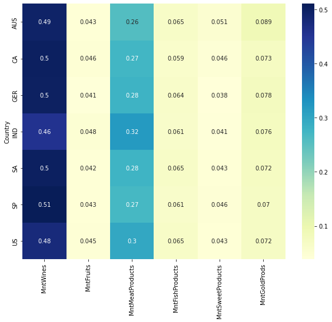

```python
#call the function amount_per_category for Country with dataframe df_not_mexico
amount_per_category(df_not_mexico,'Country')
```

### Check different channel performances

Let's calculate the percentage of purchases for all the channels.

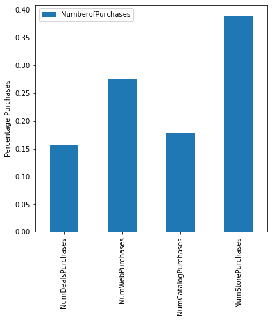

```python
# list of cols for channels

channel_cols = [col for col in df.columns if 'Purchases' in col]

#making dataframe of columns having purchase and taking sum of them.
channels = pd.DataFrame(df[channel_cols].sum()/df.Total_Purchase.sum(), columns=['NumberofPurchases'])

# plot
channels.plot(kind='bar', figsize=(6,6))
plt.ylabel("Percentage Purchases")
plt.show()
```

**Observations**:

- We can see that the most purchases are from the stores followed by web purchases.
- Number of deal purchases and catalog purchases are low.